# Bayes Warm-Up

Jim Albert

7/20/2017

#### Proportion Problem

We introduce Bayesian thinking by means of a popular introductory statistics inference problem: learning about a population proportion. This example is artificial, but it should serve as a good introduction to Bayesian thinking.

Suppose I am interested in learning about $p$, the proportion of “top 100” male tennis players on the ATP tour that are 24 years or younger.

#### Prior

First, I want to construct a prior that reflects my beliefs about the location of $p$. Here are a couple of statements:

1. I believe $p$ is equally likely to be smaller or larger than 0.25.
2. I am 90% confident that $p$ is smaller than 0.4.

In other words …

1. $P(p < 0.25) = 0.5$
2. $P(p < 0.4) = 0.9$

Using the `beta.select()` function in the `LearnBayes` package, I find the shape parameters of a beta curve that match this prior information.

```r
library(LearnBayes)
(ab <- beta.select(list(x=.25, p=.5), list(x=.4, p=.9)))
```

```
## [1]  4.40 12.53
```

A beta curve with shape parameters a = 4.4 and b = 12.53 is an approximation to my prior beliefs.

The function `beta_draw()` in the `TeachBayes` package will display a beta prior.

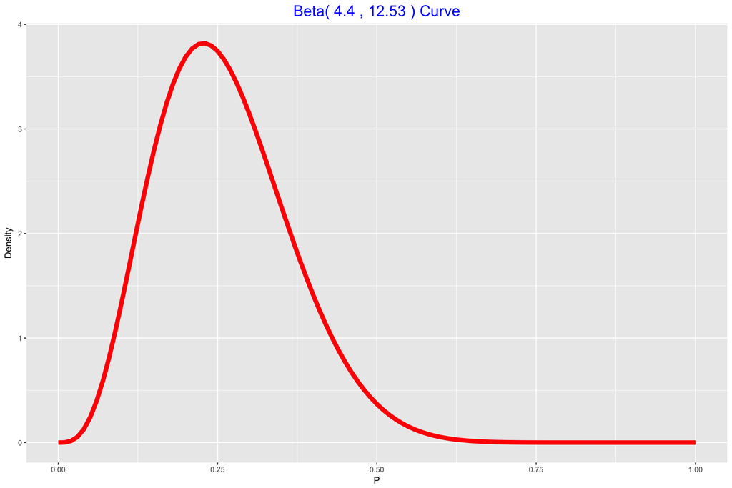

```r
library(TeachBayes)
beta_draw(ab)
```

#### Data

I randomly choose 20 player ranks from 1 to 100 and find the ages of those players with those ranks.

Here are the player ranks:

```r
set.seed(100)
sample(100, 20)
```

```
##  [1] 31 26 55  6 45 46 77 35 51 16 57 79 25 93 66 90 18 30 83 56
```

Here are the ages of these ranked players:

```r
ages <- c(27, 35, 33, 28, 31, 35, 31, 31, 25, 26,
          24, 25, 38, 32, 27, 21, 23, 31, 35, 32)
```

Compute the number of successes (ages less or equal to 24) and failures (over 24):

```r
s <- sum(ages <= 24)
f <- 20 - s
c(s, f)
```

```
## [1]  3 17
```

#### Posterior

Here we have a conjugate prior, so the posterior will also be beta with updated parameters:

```r
(ab1 <- c(ab[1] + s, ab[2] + f))
```

```
## [1]  7.40 29.53
```

#### Triplot

The `triplot()` function in the `LearnBayes` package shows the prior, likelihood, and posterior in a single graph.

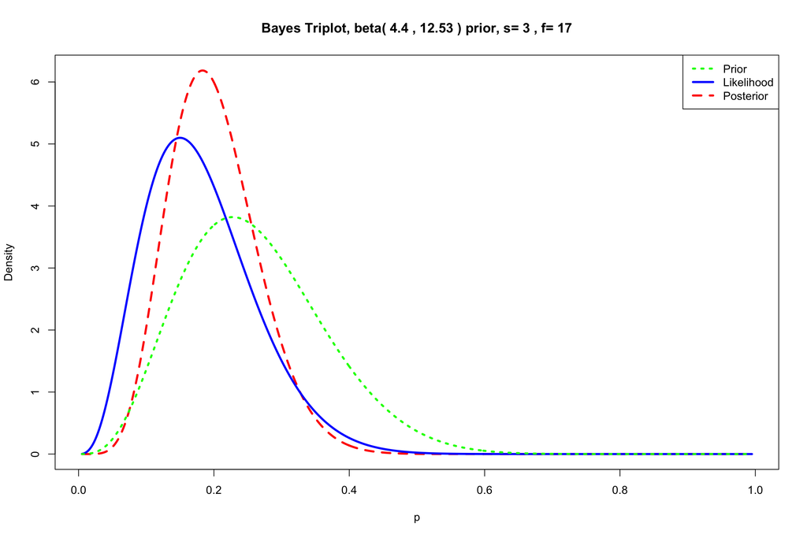

```r
triplot(ab, c(s, f))
```

#### Inference

We’ll take a simulation approach to summarize the posterior. The posterior density is beta and so we simulate 1000 draws from a beta curve, and inferences are found by summarizing this simulated posterior sample.

I do the simulation using the `rbeta()` function and construct a density estimates of the draws.

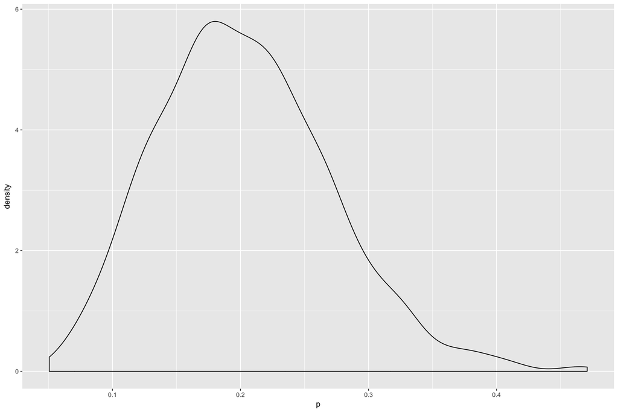

```r
sim_p <- rbeta(1000, ab1[1], ab1[2])
library(ggplot2)
ggplot(data.frame(p=sim_p), aes(p)) + geom_density()
```

A standard type of inference is a Bayesian probability interval. I find a 90% interval by extracting the 5th and 95th percentiles of the simulated values from the posterior.

```r
quantile(sim_p, c(0.05, 0.95))
```

```
##        5%       95%
## 0.1023813 0.3230402
```

By the way, I have a function `beta_interval` that will compute and display a 90% probability interval in this simulation. We can compare this exact interval with the one produced by simulation.

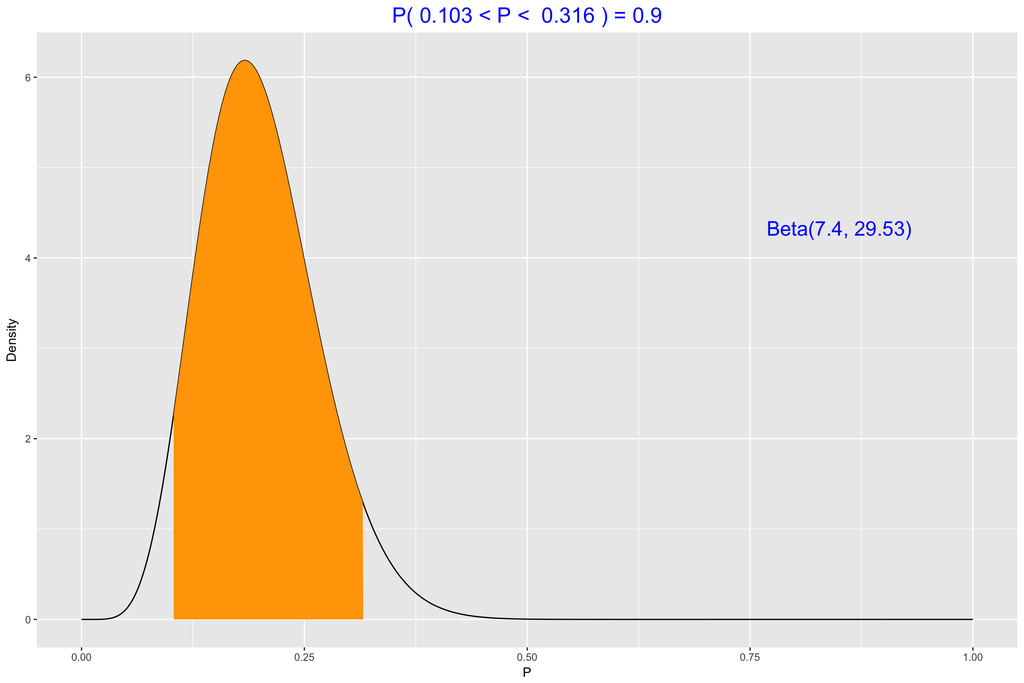

```r
beta_interval(0.90, ab1)
```

#### Prediction

Suppose I am interested in predicting the number of young (24 or under) players in a new random sample of 20 players.

We predict from the (posterior) predictive density. We do this in two stages:

1. (Inferential uncertainty) We simulate 1000 values of $p$ from the posterior.

```r
sim_p <- rbeta(1000, ab1[1], ab1[2])
```

2. (Sampling uncertainty) For each simulated draw of $p$, we simulate the number of young players $y_s$ from a binomial distribution with sample size 20 and probability of success $p$.

```r
sim_ys <- rbinom(1000, size=20, prob=sim_p)
```

Here is a histogram of the simulated values of $y_s$ using the `bar_plot` function from the `TeachBayes` package.

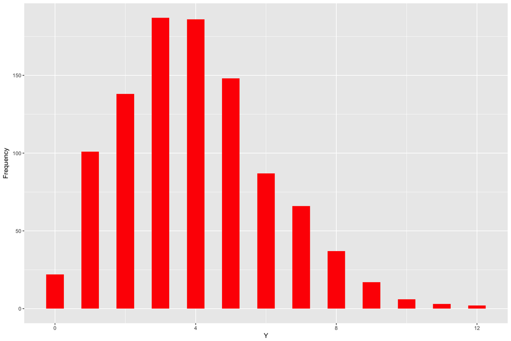

```r
library(TeachBayes)
bar_plot(sim_ys)
```

I use the `quantile` function again to find a 90% prediction interval for the number of young players in a future sample of 20 “top 100” ATP players.

```r
quantile(sim_ys, c(0.05, 0.95))
```

```
##  5% 95%
##   1   8
```